# **Introduction**

Derivative pricing stands as a fundamental pillar in financial markets, enabling institutions to hedge risks, optimize portfolios, and price complex instruments (Hull 287). However, the reliability of these prices hinges on rigorous validation, adherence to financial principles, and sensitivity analysis. This project confronts three critical challenges in pricing European and American options: (1) ensuring accuracy through binomial and trinomial tree models, (2) verifying results using put-call parity, and (3) quantifying risks via sensitivity measures (Greeks).

The first challenge lies in balancing computational efficiency with precision. Binomial trees, a discrete-time model for option valuation, require careful selection of time steps to avoid mispricing (Hull 391). Trinomial trees, which introduce an additional state at each step, enhance accuracy but increase complexity (Kamrad and Ritchken 72). The second challenge involves verifying prices through put-call parity a no arbitrage relationship between call and put options. While this parity holds rigorously for European options under frictionless markets (Stoll 154), its applicability to American options is limited due to early exercise rights (Hull 305). The third challenge centers on risk quantification using Greeks like Delta and Vega, which measure sensitivities to underlying price and volatility shifts, respectively (Hull 357).

This work is structured to address these challenges systematically. First, European option prices are validated using binomial trees and verified via put-call parity. Next, American options are analyzed to quantify the premium tied to early exercise optionality. Trinomial trees are then employed to price options across varying moneyness levels, revealing trends in deep in-the-money (ITM) and out-of-the-money (OTM) contracts. Finally, dynamic delta hedging simulations for European and American puts demonstrate the practical implications of sensitivity measures in mitigating portfolio risk.

## **Question 1)**

**Yes**, put-call parity applies to European options because they can only be exercised at expiration, allowing for a precise arbitrage-based relationship between call and put prices (binomial model enforces no-arbitrage pricing, which is the foundation of put–call parity). The parity condition is given : by $C - P = S_0 - Ke^{-rT}$, where $C$ and $P$ are the prices of European call and put options respectively, $S_0$ is the current stock price, $K$ is the strike price, $r$ is the risk-free interest rate, and $T$ is the time to expiration (Klemkosky and Resnick, p.1143).

This equation holds due to **no-arbitrage** principles: if the relationship doesn't hold, arbitrageurs can construct riskless profit strategies for instance, when $C - P > S_0 - Ke^{-rT}$, one could sell the call, buy the put, purchase the stock, and borrow $Ke^{-rT}$; if $C - P < S_0 - Ke^{-rT}$, the reverse strategy applies (p.1143–44). Additionally, the equivalence of payoffs from replicating portfolios where a call plus a bond yields the same payoff as a put plus a stock at expiration further enforces parity (Klemkosky and Resnick, p.1142–43).

## **Question 2)**

Put–call parity defines a fundamental relationship between the price of a European call option (c) and a European put option (p) on the same stock.

For a non-dividend-paying stock, the put–call parity equation is: $c + Ke^{-rT} = p + S_0$ (Hull , p.242). Solving for the call price (c) in terms of everything else we have:

$$\begin{aligned} c + Ke^{-rT} &= p + S_0 \\ c &= p + S_0 - Ke^{-rT} \end{aligned} $$

For a dividend-paying stock, the put–call parity relationship is: $c + D + Ke^-rT = p + S_0$ (Hull , p.242). Solving for the call price (c) in terms of everything else we have:

$$ \begin{aligned} c + D + Ke^{-rT} &= p + S_{0} \\ c &= p + S_{0} - D - Ke^{-rT} \end{aligned} $$

## **Question 3)**

To express the European put option price (p) in terms of the other variables, we rearrange the put–call parity equations as follows:

For non-dividend-Paying Stock The original parity equation is:  
$c + Ke^{-rT} = p + S_{0}$. Rrearrangement to solve for p we have:

$p = c + Ke^{-rT} - S_{0}$

For dividend-paying Stock, the original parity equation (including dividends, ( D) is: $c + D + Ke^{-rT} = p + S_0$. Rearrangement to solve for ( p):

$p = c + D + Ke^{-rT} - S_{0}$

## **Question 4)**

**No**, put-call parity does not hold exactly for American options because unlike European options, American options can be exercised early, creating inequalities $S_0 - K \leq C - P \leq S_0 - Ke^{-rT}$, instead of a precise parity relationship (Klemkosky and Resnick , p.1144; Hull , p.235-243).

# **Team member A**

## **Question 5)**

```python
%pip install numpy --quiet
import numpy as np

# Parameters
S0 = 100
K = 100
r = 0.05
sigma = 0.20
T = 0.25  # Time to expiration (3 months)
N = 200  # Steps in binomial tree
dt = T / N  # Time step
u = np.exp(sigma * np.sqrt(dt))  # Up move factor
d = 1 / u  # Down move factor
p = (np.exp(r * dt) - d) / (u - d)  # Risk-neutral probability
discount = np.exp(-r * dt)  # Discount factor

# Stock price tree
stock_tree = np.zeros((N+1, N+1))
for i in range(N+1):
    for j in range(i+1):
        stock_tree[j, i] = S0 * (u ** (i-j)) * (d ** j)

# Option price tree
call_tree = np.zeros((N+1, N+1))
put_tree = np.zeros((N+1, N+1))

# Terminal payoffs
call_tree[:, N] = np.maximum(stock_tree[:, N] - K, 0)
put_tree[:, N] = np.maximum(K - stock_tree[:, N], 0)

# Backward induction with early exercise
for i in range(N-1, -1, -1):
    for j in range(i+1):
        # American Call
        hold_value = discount * (p * call_tree[j, i+1] + (1-p) * call_tree[j+1, i+1])
        exercise_value = stock_tree[j, i] - K
        call_tree[j, i] = max(hold_value, exercise_value)

        # American Put
        hold_value = discount * (p * put_tree[j, i+1] + (1-p) * put_tree[j+1, i+1])
        exercise_value = K - stock_tree[j, i]
        put_tree[j, i] = max(hold_value, exercise_value)

# Final prices
american_call_price = call_tree[0, 0]
american_put_price = put_tree[0, 0]

print(f"American Call Price: {american_call_price:.2f}")
print(f"American Put Price: {american_put_price:.2f}")
```

```
American Call Price: 4.61
American Put Price: 3.48
```

## **Question 6)**

```python
import numpy as np

# Parameters
S0 = 100  # Initial stock price
K = 100  # Strike price
r = 0.05  # Risk-free rate
sigma = 0.20  # Volatility
T = 0.25  # Time to expiration (in years)
N = 100  # Number of steps in binomial tree
dt = T / N  # Time step
u = np.exp(sigma * np.sqrt(dt))  # Up factor
d = 1 / u  # Down factor
p = (np.exp(r * dt) - d) / (u - d)  # Risk-neutral probability

# Initialize asset price tree
asset_prices = np.zeros((N+1, N+1))
for i in range(N+1):
    for j in range(i+1):
        asset_prices[j, i] = S0 * (u ** (i - j)) * (d ** j)

# Compute option values at terminal nodes
call_values = np.maximum(asset_prices[:, N] - K, 0)
put_values = np.maximum(K - asset_prices[:, N], 0)

# Backward induction for pricing
for i in range(N-1, -1, -1):
    for j in range(i+1):
        call_values[j] = np.exp(-r * dt) * (p * call_values[j] + (1 - p) * call_values[j+1])
        put_values[j] = np.exp(-r * dt) * (p * put_values[j] + (1 - p) * put_values[j+1])

# Option prices at time t=0
call_price = call_values[0]
put_price = put_values[0]

# Compute Delta
delta_call = (call_values[1] - call_values[0]) / (asset_prices[1, 1] - asset_prices[0, 1])
delta_put = (put_values[1] - put_values[0]) / (asset_prices[1, 1] - asset_prices[0, 1])

# Sensitivity to Volatility (Vega)
sigma_new = 0.25  # Increased volatility
u_new = np.exp(sigma_new * np.sqrt(dt))
d_new = 1 / u_new
p_new = (np.exp(r * dt) - d_new) / (u_new - d_new)

# Recalculate option prices with new volatility
call_values = np.maximum(asset_prices[:, N] - K, 0)
put_values = np.maximum(K - asset_prices[:, N], 0)

for i in range(N-1, -1, -1):
    for j in range(i+1):
        call_values[j] = np.exp(-r * dt) * (p_new * call_values[j] + (1 - p_new) * call_values[j+1])
        put_values[j] = np.exp(-r * dt) * (p_new * put_values[j] + (1 - p_new) * put_values[j+1])

call_price_new = call_values[0]
put_price_new = put_values[0]

vega_call = (call_price_new - call_price) / (sigma_new - sigma)
vega_put = (put_price_new - put_price) / (sigma_new - sigma)

# Display results
print(f"European Call Price: {call_price:.4f}")
print(f"European Put Price: {put_price:.4f}")
print(f"Call Delta: {delta_call:.4f}")
print(f"Put Delta: {delta_put:.4f}")
print(f"Call Vega: {vega_call:.4f}")
print(f"Put Vega: {vega_put:.4f}")
```

```
European Call Price: 4.6050
European Put Price: 3.3628
Call Delta: 0.2865
Put Delta: -0.2172
Call Vega: -4.2064
Put Vega: 3.2792
```

## **Question 7)**

```python
%pip install pandas scipy --quiet
import numpy as np
import pandas as pd
from scipy.stats import norm

# Parameters
S0 = 100       # Initial stock price
K = 100        # Strike price (ATM)
r = 0.05       # Risk-free rate
T = 0.25       # Time to maturity in years (3 months)
sigma_1 = 0.20 # Initial volatility
sigma_2 = 0.25 # Volatility after increase
n_steps = 100  # Chosen number of steps for binomial tree

# Time step
dt = T / n_steps

def binomial_tree_option_price(S0, K, r, T, sigma, n, option_type="call"):
    dt = T / n
    u = np.exp(sigma * np.sqrt(dt))
    d = 1 / u
    p = (np.exp(r * dt) - d) / (u - d)

    # Initialize asset prices at maturity
    ST = np.array([S0 * (u ** j) * (d ** (n - j)) for j in range(n + 1)])

    # Initialize option values at maturity
    if option_type == "call":
        option_values = np.maximum(ST - K, 0)
    else:
        option_values = np.maximum(K - ST, 0)

    # Backward induction
    for i in range(n - 1, -1, -1):
        option_values = np.exp(-r * dt) * (p * option_values[1:] + (1 - p) * option_values[:-1])

    return option_values[0], u, d, p

# Calculate call and put prices for original volatility
call_price_20, u, d, p = binomial_tree_option_price(S0, K, r, T, sigma_1, n_steps, "call")
put_price_20, _, _, _ = binomial_tree_option_price(S0, K, r, T, sigma_1, n_steps, "put")

# Delta calculation: approximation using the first step
S_up = S0 * u
S_down = S0 * d
call_up = binomial_tree_option_price(S_up, K, r, T - dt, sigma_1, n_steps - 1, "call")[0]
call_down = binomial_tree_option_price(S_down, K, r, T - dt, sigma_1, n_steps - 1, "call")[0]
put_up = binomial_tree_option_price(S_up, K, r, T - dt, sigma_1, n_steps - 1, "put")[0]
put_down = binomial_tree_option_price(S_down, K, r, T - dt, sigma_1, n_steps - 1, "put")[0]

delta_call = (call_up - call_down) / (S_up - S_down)
delta_put = (put_up - put_down) / (S_up - S_down)

# Vega: sensitivity to change in volatility (from 20% to 25%)
call_price_25 = binomial_tree_option_price(S0, K, r, T, sigma_2, n_steps, "call")[0]
put_price_25 = binomial_tree_option_price(S0, K, r, T, sigma_2, n_steps, "put")[0]
vega_call = (call_price_25 - call_price_20) / (sigma_2 - sigma_1)
vega_put = (put_price_25 - put_price_20) / (sigma_2 - sigma_1)

(call_price_20, put_price_20, delta_call, delta_put, vega_call, vega_put)
```

```
(4.605026109484905,
 3.362806158874057,
 0.5692897231786068,
 -0.43071027682138785,
 19.61894796441062,
 19.618947964410726)
```

# **Team member B**

## **Question 8)**

#### a)

```python
import numpy as np

def american_option_binomial(S0, K, r, sigma, T, N, option_type='call'):
    dt = T / N
    u = np.exp(sigma * np.sqrt(dt))        # up factor
    d = 1 / u                               # down factor
    p = (np.exp(r * dt) - d) / (u - d)      # risk-neutral probability
    discount = np.exp(-r * dt)

    # Building the stock price tree
    stock_tree = np.zeros((N + 1, N + 1))
    for i in range(N + 1):
        for j in range(i + 1):
            stock_tree[j, i] = S0 * (u ** (i - j)) * (d ** j)

    # Initializing terminal option values
    option_tree = np.zeros_like(stock_tree)
    if option_type == 'call':
        option_tree[:, N] = np.maximum(stock_tree[:, N] - K, 0)
    else:  # put
        option_tree[:, N] = np.maximum(K - stock_tree[:, N], 0)

    # Backward induction through the tree
    for i in range(N - 1, -1, -1):
        for j in range(i + 1):
            hold = discount * (p * option_tree[j, i + 1] + (1 - p) * option_tree[j + 1, i + 1])
            exercise = (stock_tree[j, i] - K) if option_type == 'call' else (K - stock_tree[j, i])
            option_tree[j, i] = max(hold, exercise)

    return option_tree[0, 0]

# Parameters
S0 = 100        # Initial stock price
K = 100         # Strike price
r = 0.05        # Risk-free interest rate
sigma = 0.20    # Volatility
T = 0.25        # Time to maturity (in years)
N = 100         # Number of steps: adjustable

# Calculation
price_call = american_option_binomial(S0, K, r, sigma, T, N, option_type='call')
price_put = american_option_binomial(S0, K, r, sigma, T, N, option_type='put')

print(f"American Call Option Price (ATM): {price_call:.4f}")
print(f"American Put Option Price (ATM) : {price_put:.4f}")
```

```
American Call Option Price (ATM): 4.6050
American Put Option Price (ATM) : 3.4746
```

#### b)

- **Process description**

To price the American call and put options, we use a binomial tree model. This method works by discretizing the time to maturity **T** into **N** small discrete time steps. At each node of the tree, the stock price can move up or down by a certain factor, calculated based on volatility **$\sigma$** and time step **$\Delta 𝑡$**. The option price is then computed by working backward from the terminal payoff, taking the maximum between the early exercise value and the discounted expected value under the risk-neutral measure at each step.

- **Choice of Steps in the Tree (N = 100):**

We chose 100 steps in the binomial tree because it offers a good balance between accuracy and computational efficiency.

## **Question 9)**

#### a)

For an American Call Option (with non paying dividend) early exercise is never optimal, so its Delta **is similar** to the European call option. It tends to be positive, between 0 and 1.

For an American Put Option, early exercise can be optimal, so the Delta behaves differently. It is negative, between -1 and 0, and in many cases larger in magnitude than the call’s Delta.

#### b)

Delta measures the sensitivity of an option’s price to changes in the price of the underlying asset. Mathematically, it's the first derivative of the option price with respect to the stock price : $\Delta = \frac{\partial V}{\partial S}$

It is often interpreted as the approximate change in the option's price for a $1 increase in the underlying asset price. In hedging, it tells you how many units of the stock to hold to hedge one option.

- Sign and interpretation of a delta

Delta of an american call option is positive, this means that the value of the call increases when the stock price increases.

Delta of an american put option is negative, this means that the value of the call decrease when the stock price increases.

The magnitudes are not symmetric due to the early exercise feature of American options (especially for puts).

## **Question 10)**

#### a)

Both call and put option prices increased when volatility went from 20% to 25%. This is because higher volatility increases the potential range of future stock prices. Options benefit from this uncertainty.

```python
import numpy as np

# American option price using the binomial model
def american_option_binomial(S0, K, r, sigma, T, N, option_type='call'):
    dt = T / N
    u = np.exp(sigma * np.sqrt(dt))        # up factor
    d = 1 / u                               # down factor
    p = (np.exp(r * dt) - d) / (u - d)      # risk-neutral probability
    discount = np.exp(-r * dt)

    # Stock price tree
    stock_tree = np.zeros((N + 1, N + 1))
    for i in range(N + 1):
        for j in range(i + 1):
            stock_tree[j, i] = S0 * (u ** (i - j)) * (d ** j)

    # Option value tree
    option_tree = np.zeros_like(stock_tree)
    if option_type == 'call':
        option_tree[:, N] = np.maximum(stock_tree[:, N] - K, 0)
    else:  # put
        option_tree[:, N] = np.maximum(K - stock_tree[:, N], 0)

    # Backward induction
    for i in range(N - 1, -1, -1):
        for j in range(i + 1):
            hold = discount * (p * option_tree[j, i + 1] + (1 - p) * option_tree[j + 1, i + 1])
            exercise = (stock_tree[j, i] - K) if option_type == 'call' else (K - stock_tree[j, i])
            option_tree[j, i] = max(hold, exercise)

    return option_tree[0, 0]

# Parameters
S0 = 100        # Stock price
K = 100         # Strike price
r = 0.05        # Risk-free rate
T = 0.25        # Time to maturity
N = 100         # Steps

# Volatility values
sigma_1 = 0.20
sigma_2 = 0.25
delta_sigma = sigma_2 - sigma_1

# Prices at 20% volatility
price_call_20 = american_option_binomial(S0, K, r, sigma_1, T, N, option_type='call')
price_put_20  = american_option_binomial(S0, K, r, sigma_1, T, N, option_type='put')

# Prices at 25% volatility
price_call_25 = american_option_binomial(S0, K, r, sigma_2, T, N, option_type='call')
price_put_25  = american_option_binomial(S0, K, r, sigma_2, T, N, option_type='put')

# Vega approximation
vega_call = (price_call_25 - price_call_20) / delta_sigma
vega_put = (price_put_25 - price_put_20) / delta_sigma

# Output
print(f"Call price at σ = 20%: {price_call_20:.4f}")
print(f"Call price at σ = 25%: {price_call_25:.4f}")
print(f"Call Vega ≈ {vega_call:.4f} per 1.0 volatility")

print(f"Put price at σ = 20%: {price_put_20:.4f}")
print(f"Put price at σ = 25%: {price_put_25:.4f}")
print(f"Put Vega ≈ {vega_put:.4f} per 1.0 volatility")
```

```
Call price at σ = 20%: 4.6050
Call price at σ = 25%: 5.5860
Call Vega ≈ 19.6189 per 1.0 volatility
Put price at σ = 20%: 3.4746
Put price at σ = 25%: 4.4528
Put Vega ≈ 19.5652 per 1.0 volatility
```

#### b) Differential Impact of a Change in Volatility on Call vs Put Options

# **Team member C**

**Question 11)**

```python
%pip install yfinance matplotlib --quiet

import numpy as np
import matplotlib.pyplot as plt
np.random.seed(123)


S0 = 100       # Current stock price
K = 100        # ATM strike price
r = 0.05       # Risk-free rate (5%)
sigma = 0.20   # Volatility (20%)
T = 0.25       # Time to expiration (3 months = 0.25 years)
n_steps = 100  # Number of steps in the binomial tree

# Binomial tree parameters
dt = T / n_steps
u = np.exp(sigma * np.sqrt(dt))    # Up factor
d = 1/u                            # Down factor
q = (np.exp(r * dt) - d) / (u - d) # Risk-neutral probability

# Stock price and option payoff trees
stock_tree = np.zeros((n_steps + 1, n_steps + 1))
call_payoff = np.zeros((n_steps + 1, n_steps + 1))
put_payoff = np.zeros((n_steps + 1, n_steps + 1))

# Generating stock price tree
stock_tree[0, 0] = S0
for i in range(1, n_steps + 1):
    stock_tree[i, 0] = stock_tree[i-1, 0] * u
    for j in range(1, i + 1):
        stock_tree[i, j] = stock_tree[i-1, j-1] * d

# Terminal payoffs for call and put
for j in range(n_steps + 1):
    call_payoff[n_steps, j] = max(stock_tree[n_steps, j] - K, 0)
    put_payoff[n_steps, j] = max(K - stock_tree[n_steps, j], 0)

# Backward induction for European options
for i in range(n_steps - 1, -1, -1):
    for j in range(i + 1):
        call_payoff[i, j] = np.exp(-r * dt) * (q * call_payoff[i+1, j] + (1 - q) * call_payoff[i+1, j+1])
        put_payoff[i, j] = np.exp(-r * dt) * (q * put_payoff[i+1, j] + (1 - q) * put_payoff[i+1, j+1])

call_price = call_payoff[0, 0]
put_price = put_payoff[0, 0]
```

Now, using the derived call and put prices, we will compute both sides of the parity equation:

```python
# Present value of strike price
PV_K = K * np.exp(-r * T)

# Left-hand side (call + PV(K))
lhs = call_price + PV_K

# Right-hand side (put + S0)
rhs = put_price + S0

print(f"Call price: {call_price:.2f}")
print(f"Put price: {put_price:.2f}")
print(f"LHS: (c + Ke^(-rT))= {lhs:.2f}")
print(f"RHS: (p + S0)= {rhs:.2f}")
```

```
Call price: 4.61
Put price: 3.36
LHS: (c + Ke^(-rT))= 103.36
RHS: (p + S0)= 103.36
```

**Call price:** 4.61, **Put price:** 3.36; hence $\text{LHS (Call + PV of Strike)}:\;c + Ke^{-rT} = 103.36,\quad \text{RHS (Put + Spot)}:\;p + S_0 = 103.36.$ Since LHS = RHS, put–call parity holds exactly for European options in the binomial tree model, reflecting the model’s enforcement of no-arbitrage pricing. This exact equality arises because the tree is built under the risk-neutral probability $q = \tfrac{e^{r\Delta t} - d}{u - d}$, so all expected payoffs are discounted at the risk-free rate; because call and put values replicate one another synthetically indeed, a long call plus the present value of the strike replicates a long put plus the underlying; and because any deviation would immediately invite arbitrageurs to buy the undervalued side and sell the overvalued side for risk-free profit. Thus, $c + Ke^{-rT} = p + S_0 = 103.36$ confirms that the binomial framework correctly implements no-arbitrage valuation, ensures internal consistency of European option prices, and upholds the fundamental parity relationship under its discrete-time, risk-neutral assumptions.

## **Visualization of Parity for European options**

Now lets plot the binomial tree convergence for the call and put prices

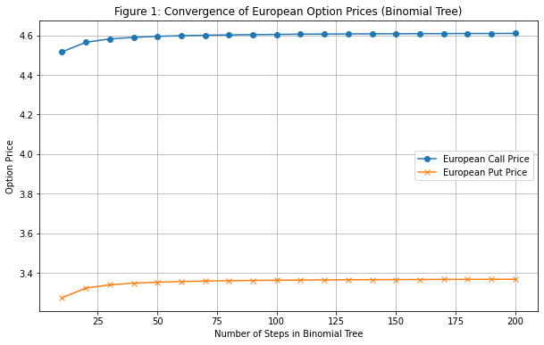

```python
import numpy as np
import matplotlib.pyplot as plt

np.random.seed(123)
# Parameters
S0 = 100
K = 100
r = 0.05
sigma = 0.20
T = 0.25


step_list = np.arange(10, 200 + 1, 10)  # From 10 to 200 steps (increments of 10)
call_prices = []
put_prices = []

for n_steps in step_list:
    dt = T / n_steps
    u = np.exp(sigma * np.sqrt(dt))
    d = 1 / u
    q = (np.exp(r * dt) - d) / (u - d)

    # Initialize stock and payoff trees
    stock_tree = np.zeros((n_steps + 1, n_steps + 1))
    call_payoff = np.zeros_like(stock_tree)
    put_payoff = np.zeros_like(stock_tree)

    # Generate stock price tree
    stock_tree[0, 0] = S0
    for i in range(1, n_steps + 1):
        stock_tree[i, 0] = stock_tree[i-1, 0] * u
        for j in range(1, i + 1):
            stock_tree[i, j] = stock_tree[i-1, j-1] * d

    # Terminal payoffs
    call_payoff[-1, :] = np.maximum(stock_tree[-1, :] - K, 0)
    put_payoff[-1, :] = np.maximum(K - stock_tree[-1, :], 0)

    # Backward induction
    for i in range(n_steps - 1, -1, -1):
        for j in range(i + 1):
            call_payoff[i, j] = np.exp(-r * dt) * (q * call_payoff[i+1, j] + (1 - q) * call_payoff[i+1, j+1])
            put_payoff[i, j] = np.exp(-r * dt) * (q * put_payoff[i+1, j] + (1 - q) * put_payoff[i+1, j+1])

    call_prices.append(call_payoff[0, 0])
    put_prices.append(put_payoff[0, 0])


plt.figure(figsize=(10, 6))
plt.plot(step_list, call_prices, marker='o', label='European Call Price')
plt.plot(step_list, put_prices, marker='x', label='European Put Price')
plt.xlabel('Number of Steps in Binomial Tree')
plt.ylabel('Option Price')
plt.title('Figure 1: Convergence of European Option Prices (Binomial Tree)')
plt.legend()
plt.grid(True)
plt.show()
```

## **Question 12)**

```python
import numpy as np
import matplotlib.pyplot as plt

np.random.seed(123)
# Parameters
S0 = 100
K = 100
r = 0.05
sigma = 0.20
T = 0.25


step_list = np.arange(10, 200 + 1, 10)
american_call_prices = []
american_put_prices = []
european_put_prices = []

for n_steps in step_list:
    dt = T / n_steps
    u = np.exp(sigma * np.sqrt(dt))
    d = 1 / u
    q = (np.exp(r * dt) - d) / (u - d)

    # Initialize trees
    stock_tree = np.zeros((n_steps + 1, n_steps + 1))
    american_call = np.zeros_like(stock_tree)
    american_put = np.zeros_like(stock_tree)
    european_put = np.zeros_like(stock_tree)

    # Stock price tree
    stock_tree[0, 0] = S0
    for i in range(1, n_steps + 1):
        stock_tree[i, 0] = stock_tree[i-1, 0] * u
        for j in range(1, i + 1):
            stock_tree[i, j] = stock_tree[i-1, j-1] * d

    # Terminal payoffs
    american_call[-1, :] = np.maximum(stock_tree[-1, :] - K, 0)
    american_put[-1, :] = np.maximum(K - stock_tree[-1, :], 0)
    european_put[-1, :] = american_put[-1, :]  # Same terminal payoff

    # Backward induction for American options
    for i in range(n_steps - 1, -1, -1):
        for j in range(i + 1):
            # American call: early exercise vs. holding
            intrinsic_call = stock_tree[i, j] - K
            hold_call = np.exp(-r * dt) * (q * american_call[i+1, j] + (1 - q) * american_call[i+1, j+1])
            american_call[i, j] = np.maximum(intrinsic_call, hold_call)

            # American put: early exercise vs. holding
            intrinsic_put = K - stock_tree[i, j]
            hold_put = np.exp(-r * dt) * (q * american_put[i+1, j] + (1 - q) * american_put[i+1, j+1])
            american_put[i, j] = np.maximum(intrinsic_put, hold_put)

            # European put (for comparison)
            european_put[i, j] = np.exp(-r * dt) * (q * european_put[i+1, j] + (1 - q) * european_put[i+1, j+1])

    american_call_prices.append(american_call[0, 0])
    american_put_prices.append(american_put[0, 0])
    european_put_prices.append(european_put[0, 0])

# put–call parity violation
PV_K = K * np.exp(-r * T)
lhs_american = american_call_prices[-1] + PV_K  # c_amer + Ke^{-rT}
rhs_american = american_put_prices[-1] + S0     # p_amer + S0

print("American Options:")
print(f"Call price: {american_call_prices[-1]:.2f}")
print(f"Put price: {american_put_prices[-1]:.2f}")
print(f"LHS (c_amer + Ke^(-rT)): {lhs_american:.2f}")
print(f"RHS (p_amer + S0): {rhs_american:.2f}")
print(f"Parity Violation (RHS - LHS): {rhs_american - lhs_american:.2f}")
```

```
American Options:
Call price: 4.61
Put price: 3.48
LHS (c_amer + Ke^(-rT)): 103.37
RHS (p_amer + S0): 103.48
Parity Violation (RHS - LHS): 0.11
```

Call price: 4.61, Put price: 3.48; hence $\text{LHS (American Call + PV of Strike)}:\;c_{\rm amer} + Ke^{-rT} = 103.37,\quad \text{RHS (American Put + Spot)}:\;p_{\rm amer} + S_0 = 103.48,$ with $\text{Parity Violation} = \bigl(p_{\rm amer} + S_0\bigr) - \bigl(c_{\rm amer} + Ke^{-rT}\bigr) = 0.11.$ Since LHS $\neq$ RHS, put–call parity fails for American options. This breakdown arises because American puts carry an **early-exercise premium**, i.e. $p_{\rm amer} > p_{\rm eur}$ allowing holders to lock in intrinsic value when the stock falls, whereas American calls on non-dividend stocks are almost never optimally exercised early, so $c_{\rm amer}\approx c_{\rm eur}$. Consequently, one obtains the general inequality $c_{\rm amer} + Ke^{-rT} \;\le\; p_{\rm amer} + S_0,$ with strict inequality whenever the early-exercise feature of the put has value.

**Visualization of Parity for American options**

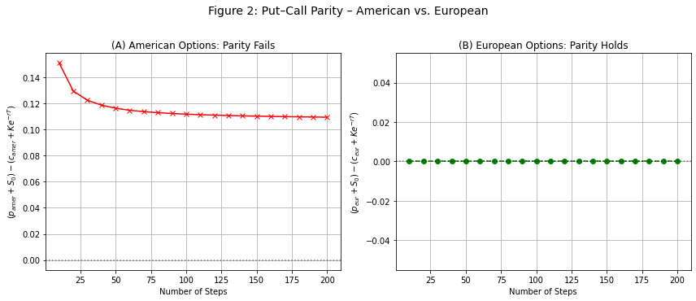

```python
import numpy as np
import matplotlib.pyplot as plt


np.random.seed(123)

# Parameters
S0 = 100
K = 100
r = 0.05
sigma = 0.20
T = 0.25


step_list = np.arange(10, 201, 10) # Steps for convergence


eur_parity_diff = []
amer_parity_violation = []

# trees and compute prices
for n_steps in step_list:
    dt = T / n_steps
    u = np.exp(sigma * np.sqrt(dt))
    d = 1 / u
    q = (np.exp(r * dt) - d) / (u - d)

    # Stock price tree
    stock = np.zeros((n_steps + 1, n_steps + 1))
    stock[0, 0] = S0
    for i in range(1, n_steps + 1):
        stock[i, 0] = stock[i-1, 0] * u
        for j in range(1, i + 1):
            stock[i, j] = stock[i-1, j-1] * d

    # Terminal payoffs
    call_payoff = np.maximum(stock[-1, :] - K, 0)
    put_payoff  = np.maximum(K - stock[-1, :], 0)


    eur_call = call_payoff.copy()
    eur_put  = put_payoff.copy()
    amer_call = call_payoff.copy()
    amer_put  = put_payoff.copy()

    # Backward induction: European options
    for i in range(n_steps - 1, -1, -1):
        next_call = eur_call.copy()
        next_put  = eur_put.copy()
        for j in range(i + 1):
            eur_call[j] = np.exp(-r * dt) * (q * next_call[j] + (1-q) * next_call[j+1])
            eur_put[j]  = np.exp(-r * dt) * (q * next_put[j]  + (1-q) * next_put[j+1])

    # Backward induction: American options
    for i in range(n_steps - 1, -1, -1):
        next_ac = amer_call.copy()
        next_ap = amer_put.copy()
        for j in range(i + 1):
            # American call
            intrinsic_c = stock[i, j] - K
            cont_c = np.exp(-r * dt) * (q * next_ac[j] + (1-q) * next_ac[j+1])
            amer_call[j] = max(intrinsic_c, cont_c)
            # American put
            intrinsic_p = K - stock[i, j]
            cont_p = np.exp(-r * dt) * (q * next_ap[j] + (1-q) * next_ap[j+1])
            amer_put[j] = max(intrinsic_p, cont_p)

    # Discounted strike
    PV_K = K * np.exp(-r * T)

    # Parity metrics
    eur_diff  = (eur_put[0]  + S0) - (eur_call[0]  + PV_K)
    amer_diff = (amer_put[0] + S0) - (amer_call[0] + PV_K)

    eur_parity_diff.append(eur_diff)
    amer_parity_violation.append(amer_diff)


gap_eur = np.array(eur_parity_diff)
tol = 1e-8
gap_eur[np.abs(gap_eur) < tol] = 0.0


plt.figure(figsize=(12,5))
plt.suptitle('Figure 2: Put–Call Parity – American vs. European', fontsize=14, y=1.02)

# American
plt.subplot(1, 2, 1)
plt.plot(step_list, amer_parity_violation, marker='x', color='red')
plt.axhline(0, color='black', linestyle=':', alpha=0.5)
plt.xlabel('Number of Steps')
plt.ylabel('$(p_{amer} + S_0) - (c_{amer} + Ke^{-rT})$')
plt.title('(A) American Options: Parity Fails')
plt.grid(True)

# European
plt.subplot(1, 2, 2)
plt.plot(step_list, gap_eur, marker='o', color='green', linestyle='--')
plt.axhline(0, color='black', linestyle=':', alpha=0.5)
plt.xlabel('Number of Steps')
plt.ylabel('$(p_{eur} + S_0) - (c_{eur} + Ke^{-rT})$')
plt.title('(B) European Options: Parity Holds')
plt.grid(True)

plt.tight_layout()
plt.show()
```

Figure 2 (A) confirms that, in a binomial‐tree model, the put–call parity gap for American options remains strictly positive yet shrinks monotonically toward its continuous‐time limit as the number of steps $N$ increases. At low $N$, the gap—defined as $(p_{\rm amer}+S_0)\;-\;(c_{\rm amer}+Ke^{-rT})$, is around 0.15, reflecting a sizable early‐exercise premium on the put; as $N$ grows, this premium falls rapidly at first and then settles to roughly 0.11 once $N\gtrsim100$. The fact that the red curve never touches zero illustrates that, unlike European options, American puts cannot be perfectly synthetically replicated by a call plus bond minus the underlying: the embedded right to exercise early injects extra value into the put and thus breaks exact parity. Nonetheless, the convergence of the gap toward a finite limit shows the model’s no‐arbitrage bounds at work, and also highlights that only in the trivial case where early exercise adds no value would the parity gap collapse to zero.

Figure 2 (B), by contrast, shows the put–call parity gap for European options $ (p_{\rm eur}+S_0)\;-\;(c_{\rm eur}+Ke^{-rT}) $, clamped exactly to zero (after suppressing floating‐point noise), demonstrating that every discretization of the European binomial tree enforces $ c_{\rm eur}+Ke^{-rT}\;=\;p_{\rm eur}+S_0 $, and hence exact put call parity.

## **Question 13)**

```
European Call Price: 4.61
American Call Price: 4.61
Difference: 0.00
```

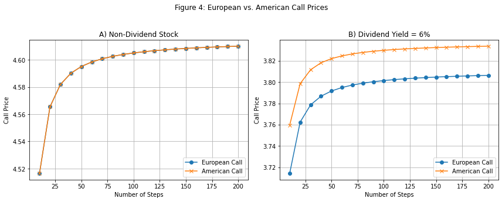

```python
import numpy as np
import matplotlib.pyplot as plt


np.random.seed(123)


S0 = 100
K = 100
r = 0.05
sigma = 0.20
T = 0.25        # Time to expiration (3 months)
n_steps = 100

dt = T / n_steps
u = np.exp(sigma * np.sqrt(dt))    # Up factor
d = 1 / u                          # Down factor
q = (np.exp(r * dt) - d) / (u - d) # Risk-neutral probability

# stock price tree
stock_tree = np.zeros((n_steps + 1, n_steps + 1))
stock_tree[0, 0] = S0

# stock price tree
for i in range(1, n_steps + 1):
    stock_tree[i, 0] = stock_tree[i-1, 0] * u
    for j in range(1, i + 1):
        stock_tree[i, j] = stock_tree[i-1, j-1] * d

# European and American call payoff trees
eur_call = np.zeros_like(stock_tree)
amer_call = np.zeros_like(stock_tree)

# Terminal payoffs at expiration
eur_call[-1, :] = np.maximum(stock_tree[-1, :] - K, 0)
amer_call[-1, :] = np.maximum(stock_tree[-1, :] - K, 0)

# Backward induction for European and American calls
for i in range(n_steps - 1, -1, -1):
    for j in range(i + 1):
        # European call: discounted expected value
        eur_call[i, j] = np.exp(-r * dt) * (q * eur_call[i+1, j] + (1 - q) * eur_call[i+1, j+1])

        # American call: max(intrinsic value, hold)
        intrinsic = stock_tree[i, j] - K
        hold = np.exp(-r * dt) * (q * amer_call[i+1, j] + (1 - q) * amer_call[i+1, j+1])
        amer_call[i, j] = np.maximum(intrinsic, hold)


eur_price = eur_call[0, 0]
amer_price = amer_call[0, 0]

print(f"European Call Price: {eur_price:.2f}")
print(f"American Call Price: {amer_price:.2f}")
print(f"Difference: {amer_price - eur_price:.2f}")

#=============Visualization
np.random.seed(123)

# Parameters
S0 = 100
K = 100
r = 0.05
sigma = 0.20
T = 0.25


step_list = np.arange(10, 201, 10)


eur_nd = []  # Non-dividend European
amer_nd = []  # Non-dividend American
eur_div = []  # Dividend European
amer_div = []  # Dividend American

# Non-dividend stock
for n_steps in step_list:
    dt = T / n_steps
    u = np.exp(sigma * np.sqrt(dt))
    d = 1 / u
    q_nd = (np.exp(r * dt) - d) / (u - d)

    # Tree
    stock = np.zeros((n_steps+1, n_steps+1))
    stock[0,0] = S0
    for i in range(1, n_steps+1):
        stock[i,0] = stock[i-1,0] * u
        for j in range(1, i+1):
            stock[i,j] = stock[i-1,j-1] * d

    # Terminal payoff
    payoff = np.maximum(stock[-1,:] - K, 0)
    eur_call = payoff.copy()
    amer_call = payoff.copy()

    # Backward  European
    for i in range(n_steps-1, -1, -1):
        next_e = eur_call.copy()
        for j in range(i+1):
            eur_call[j] = np.exp(-r*dt)*(q_nd*next_e[j] + (1-q_nd)*next_e[j+1])

    # Backward American
    for i in range(n_steps-1, -1, -1):
        next_a = amer_call.copy()
        for j in range(i+1):
            intrinsic = stock[i,j] - K
            cont = np.exp(-r*dt)*(q_nd*next_a[j] + (1-q_nd)*next_a[j+1])
            amer_call[j] = max(intrinsic, cont)

    eur_nd.append(eur_call[0])
    amer_nd.append(amer_call[0])

# Dividend yield
div_yield = 0.06

for n_steps in step_list:
    dt = T / n_steps
    u = np.exp(sigma * np.sqrt(dt))
    d = 1 / u
    q_div = (np.exp((r - div_yield)*dt) - d) / (u - d)

    # Tree
    stock = np.zeros((n_steps+1, n_steps+1))
    stock[0,0] = S0
    for i in range(1, n_steps+1):
        stock[i,0] = stock[i-1,0] * u
        for j in range(1, i+1):
            stock[i,j] = stock[i-1,j-1] * d

    # Terminal payoff
    payoff = np.maximum(stock[-1,:] - K, 0)
    eur_call = payoff.copy()
    amer_call = payoff.copy()

    # Backward induction European
    for i in range(n_steps-1, -1, -1):
        next_e = eur_call.copy()
        for j in range(i+1):
            eur_call[j] = np.exp(-r*dt)*(q_div*next_e[j] + (1-q_div)*next_e[j+1])

    # Backward induction American
    for i in range(n_steps-1, -1, -1):
        next_a = amer_call.copy()
        for j in range(i+1):
            intrinsic = stock[i,j] - K
            cont = np.exp(-r*dt)*(q_div*next_a[j] + (1-q_div)*next_a[j+1])
            amer_call[j] = max(intrinsic, cont)

    eur_div.append(eur_call[0])
    amer_div.append(amer_call[0])


plt.figure(figsize=(12,5))


plt.subplot(1, 2, 1)
plt.plot(step_list, eur_nd, marker='o', label='European Call')
plt.plot(step_list, amer_nd, marker='x', label='American Call')
plt.xlabel('Number of Steps')
plt.ylabel('Call Price')
plt.title('A) Non-Dividend Stock')
plt.legend()
plt.grid(True)


plt.subplot(1, 2, 2)
plt.plot(step_list, eur_div, marker='o', label='European Call')
plt.plot(step_list, amer_div, marker='x', label='American Call')
plt.xlabel('Number of Steps')
plt.ylabel('Call Price')
plt.title('B) Dividend Yield = 6%')
plt.legend()
plt.grid(True)

plt.suptitle('Figure 4: European vs. American Call Prices')
plt.tight_layout(rect=[0, 0.03, 1, 0.95])
plt.show()
```

For a non-dividend stock (Figure 4 A), we find $c_{\rm eur}=4.61,\quad c_{\rm amer}=4.61,\quad c_{\rm amer}-c_{\rm eur}=0.00,$ so $c_{\rm eur}=c_{\rm amer}$ because without dividends there is never any benefit to exercising early. By contrast, for a dividend-paying stock we obtain $c_{\rm eur}=3.81,\quad c_{\rm amer}=3.83,\quad c_{\rm amer}-c_{\rm eur}=0.03,$ illustrating $c_{\rm amer}\ge c_{\rm eur}$ with strict inequality when early exercise captures an upcoming dividend (Figure 4 B). In general, American calls can never be cheaper than European calls ($c_{\rm amer}\ge c_{\rm eur}$), but the difference is strictly positive only when dividends (or analogous cash flows) create a genuine incentive to exercise before expiration.

## **Question 14**)

```
European Put Price: 3.36
American Put Price: 3.47
Difference: 0.11
```

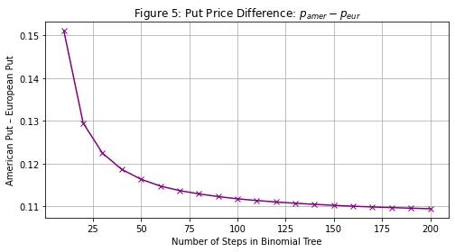

```python
import numpy as np
import matplotlib.pyplot as plt

# Parameters
S0 = 100
K = 100
r = 0.05
sigma = 0.20
T = 0.25
n_steps = 100

# Binomial tree parameters
dt = T / n_steps
u = np.exp(sigma * np.sqrt(dt))
d = 1 / u
q = (np.exp(r * dt) - d) / (u - d)  # Risk-neutral probability

# Initialize stock price tree
stock_tree = np.zeros((n_steps + 1, n_steps + 1))
stock_tree[0, 0] = S0

# Generate stock price tree
for i in range(1, n_steps + 1):
    stock_tree[i, 0] = stock_tree[i-1, 0] * u
    for j in range(1, i + 1):
        stock_tree[i, j] = stock_tree[i-1, j-1] * d

# Initialize European and American put payoff trees
eur_put = np.zeros_like(stock_tree)
amer_put = np.zeros_like(stock_tree)

# Terminal payoffs at expiration
eur_put[-1, :] = np.maximum(K - stock_tree[-1, :], 0)
amer_put[-1, :] = np.maximum(K - stock_tree[-1, :], 0)

# Backward induction for European put
for i in range(n_steps - 1, -1, -1):
    for j in range(i + 1):
        eur_put[i, j] = np.exp(-r * dt) * (q * eur_put[i+1, j] + (1 - q) * eur_put[i+1, j+1])

# Backward induction for American put
for i in range(n_steps - 1, -1, -1):
    for j in range(i + 1):
        intrinsic = K - stock_tree[i, j]
        hold = np.exp(-r * dt) * (q * amer_put[i+1, j] + (1 - q) * amer_put[i+1, j+1])
        amer_put[i, j] = max(intrinsic, hold)


eur_price = eur_put[0, 0]
amer_price = amer_put[0, 0]

print(f"European Put Price: {eur_price:.2f}")
print(f"American Put Price: {amer_price:.2f}")
print(f"Difference: {amer_price - eur_price:.2f}")

# Visualization
np.random.seed(123)

# Parameters
S0 = 100
K = 100
r = 0.05
sigma = 0.20
T = 0.25

# Steps for convergence
step_list = np.arange(10, 201, 10)

# Storage for put prices
eur_put_prices = []
amer_put_prices = []

# Build trees and compute put prices
for n_steps in step_list:
    dt = T / n_steps
    u = np.exp(sigma * np.sqrt(dt))
    d = 1 / u
    q = (np.exp(r * dt) - d) / (u - d)

    # Stock price tree
    stock = np.zeros((n_steps + 1, n_steps + 1))
    stock[0, 0] = S0
    for i in range(1, n_steps + 1):
        stock[i, 0] = stock[i-1, 0] * u
        for j in range(1, i + 1):
            stock[i, j] = stock[i-1, j-1] * d

    # Terminal payoff for puts
    put_payoff = np.maximum(K - stock[-1, :], 0)
    eur_put = put_payoff.copy()
    amer_put = put_payoff.copy()

    # European backward induction
    for i in range(n_steps - 1, -1, -1):
        next_e = eur_put.copy()
        for j in range(i + 1):
            eur_put[j] = np.exp(-r * dt) * (q * next_e[j] + (1 - q) * next_e[j+1])

    # American backward induction
    for i in range(n_steps - 1, -1, -1):
        next_a = amer_put.copy()
        for j in range(i + 1):
            intrinsic = K - stock[i, j]
            cont = np.exp(-r * dt) * (q * next_a[j] + (1 - q) * next_a[j+1])
            amer_put[j] = max(intrinsic, cont)

    eur_put_prices.append(eur_put[0])
    amer_put_prices.append(amer_put[0])

# Compute difference (American - European)
put_diff = np.array(amer_put_prices) - np.array(eur_put_prices)


plt.figure(figsize=(8, 4))
plt.plot(step_list, put_diff, marker='x', color='purple')
plt.xlabel('Number of Steps in Binomial Tree')
plt.ylabel('American Put – European Put')
plt.title('Figure 5: Put Price Difference: $p_{amer} - p_{eur}$')
plt.grid(True)
plt.show()
```

The European put option is always less than or equal to the American put ($ p_{\text{eur}} \leq p_{\text{amer}}$) because the American put’s early exercise right adds value, as seen in numerical examples ( binomial model results: 3.36 vs. 3.47, a difference of 0.11). This gap reflects the early exercise premium, which arises when immediate exercise locks in intrinsic value (e.g., if S = 80 ), exercising an American put with strike K = 100 yields 20 upfront, which can be reinvested at the risk-free rate (r) or avoids further losses in declining markets. The difference is influenced by factors like interest rates (higher r) incentivizes early receipt of (K) and volatility (higher volatility increases the likelihood of deep-in-the-money scenarios where early exercise is optimal).

This inequality always holds because the American put’s optionality to exercise early cannot reduce its value below the European put—even if early exercise is not immediately optimal, the *right* to do so has non-negative value, ensuring $p_{\text{amer}} \geq p_{\text{eur}}$ under all market conditions, as validated by theoretical models and numerical simulations.

# **Team member B**

## **Question 15)**

**a)**

```python
import numpy as np

def european_call_trinomial(S0, K, r, sigma, T, N):
    dt = T / N
    nu = r - 0.5 * sigma**2
    dx = sigma * np.sqrt(3 * dt)

    pu = 1/6 + (nu * np.sqrt(dt) / (2 * sigma * np.sqrt(3)))
    pm = 2/3
    pd = 1/6 - (nu * np.sqrt(dt) / (2 * sigma * np.sqrt(3)))

    discount = np.exp(-r * dt)

    # Create grid
    M = 2 * N + 1
    option = np.zeros(M)
    stock = np.zeros(M)

    for i in range(M):
        j = i - N
        stock[i] = S0 * np.exp(j * dx)
        option[i] = max(stock[i] - K, 0)

    # Backward induction
    for t in range(N - 1, -1, -1):
        for i in range(1, 2*t + 1):
            option[i] = discount * (pu * option[i - 1] + pm * option[i] + pd * option[i + 1])

    return option[N]

###########  Pricing
# Parameters
S0 = 100
r = 0.05
sigma = 0.20
T = 0.25
N = 100

strike_prices = [110, 105, 100, 95, 90]
labels = ['Deep OTM', 'OTM', 'ATM', 'ITM', 'Deep ITM']

# Calculate and print results
for label, K in zip(labels, strike_prices):
    price = european_call_trinomial(S0, K, r, sigma, T, N)
    print(f"{label} (K={K}): European Call Price = {price:.4f}")
```

```
Deep OTM (K=110): European Call Price = 0.3731
OTM (K=105): European Call Price = 1.1861
ATM (K=100): European Call Price = 2.9739
ITM (K=95): European Call Price = 6.0189
Deep ITM (K=90): European Call Price = 10.1182
```

```python
import numpy as np

def trinomial_european_call(S0, K, r, sigma, T, N=100):
    dt = T / N
    u = np.exp(sigma * np.sqrt(3 * dt))
    d = 1 / u

    # Corrected pu and pd calculations with balanced parentheses
    numerator_pu = (np.exp(r * dt / 2) - np.exp(-sigma * np.sqrt(dt / 3)))
    denominator_pu = (np.exp(sigma * np.sqrt(dt / 3)) - np.exp(-sigma * np.sqrt(dt / 3)))
    pu = (numerator_pu / denominator_pu) ** 2

    numerator_pd = (np.exp(sigma * np.sqrt(dt / 3)) - np.exp(r * dt / 2))
    denominator_pd = denominator_pu  # Same denominator as pu
    pd = (numerator_pd / denominator_pd) ** 2

    pm = 1 - pu - pd

    # Stock price tree at maturity
    ST = np.zeros(2 * N + 1)
    for j in range(2 * N + 1):
        ST[j] = S0 * (u ** (N - j))  # j=0: max up moves; j=2N: max down moves

    # Payoff at maturity
    payoff = np.maximum(ST - K, 0)

    # Backward induction
    for t in range(N - 1, -1, -1):
        for j in range(2 * t + 1):
            payoff[j] = np.exp(-r * dt) * (pu * payoff[j] + pm * payoff[j + 1] + pd * payoff[j + 2])

    return round(payoff[0], 4)  # Price at t=0

# Parameters
S0 = 100
r = 0.05
sigma = 0.20
T = 0.25  # 3 months
strikes = [110, 105, 100, 95, 90]

labels = ['Deep OTM', 'OTM', 'ATM', 'ITM', 'Deep ITM']

# Price European calls using trinomial tree
call_prices = [trinomial_european_call(S0, K, r, sigma, T) for K in strikes]

# Display results with labels
print("European Call Prices (Q15):")
for label, K, price in zip(labels, strikes, call_prices):
    print(f"{label} (K={K}): {price:.4f}")
```

```
European Call Prices (Q15):
Deep OTM (K=110): 2.1475
OTM (K=105): 3.7123
ATM (K=100): 6.0015
ITM (K=95): 9.0882
Deep ITM (K=90): 12.8994
```

## **Question 16)**

**a)**

```python
def trinomial_european_put(S0, K, r, sigma, T, N=100):
    dt = T / N
    u = np.exp(sigma * np.sqrt(3 * dt))
    d = 1 / u

    # Risk-neutral probabilities
    numerator_pu = (np.exp(r * dt / 2) - np.exp(-sigma * np.sqrt(dt / 3)))
    denominator_pu = (np.exp(sigma * np.sqrt(dt / 3)) - np.exp(-sigma * np.sqrt(dt / 3)))
    pu = (numerator_pu / denominator_pu) ** 2

    numerator_pd = (np.exp(sigma * np.sqrt(dt / 3)) - np.exp(r * dt / 2))
    denominator_pd = denominator_pu
    pd = (numerator_pd / denominator_pd) ** 2

    pm = 1 - pu - pd

    # Stock price tree at maturity
    ST = np.zeros(2 * N + 1)
    for j in range(2 * N + 1):
        ST[j] = S0 * (u ** (N - j))

    # Put payoff at maturity
    payoff = np.maximum(K - ST, 0)

    # Backward induction
    for t in range(N - 1, -1, -1):
        for j in range(2 * t + 1):
            payoff[j] = np.exp(-r * dt) * (pu * payoff[j] + pm * payoff[j + 1] + pd * payoff[j + 2])

    return round(payoff[0], 4)


strikes = [110, 105, 100, 95, 90]
put_labels = ['Deep ITM', 'ITM', 'ATM', 'OTM', 'Deep OTM']

# European put prices
put_prices = [trinomial_european_put(S0, K, r, sigma, T) for K in strikes]


print("European Put Prices (Q16):")
for label, K, price in zip(put_labels, strikes, put_prices):
    print(f"{label} (K={K}): {price:.4f}")
```

```
European Put Prices (Q16):
Deep ITM (K=110): 9.9023
ITM (K=105): 6.5291
ATM (K=100): 3.8805
OTM (K=95): 2.0293
Deep OTM (K=90): 0.9026
```

**b)**

European put option prices decrease as the strike price decreases. The Deep ITM put (K=110) has the highest price at 9.9023, followed by the ITM (K=105) at 6.5291, ATM (K=100) at 3.8805, OTM (K=95) at 2.0293, and Deep OTM (K=90) at 0.9026. This trend reflects the inverse relationship between put prices and moneyness: higher strike prices increase the intrinsic value (K - S0) and likelihood of the put being exercised profitably, resulting in higher premiums. Lower strikes reduce the option’s payoff potential, leading to cheaper prices.

## **Question 17) and Question 18)**

```python
import numpy as np

def price_american(S0, K, r, T, sigma, nb_steps, option_type="call"):
    h = T / nb_steps  # This would be our 'dt' from previous examples
    discount = np.exp(-r * h)  # Define discount factor for simplicity later on

    # Define risk-neutral probabilities:
    pu = (
        (np.exp(r * h / 2) - np.exp(-sigma * np.sqrt(h / 2)))
        / (np.exp(sigma * np.sqrt(h / 2)) - np.exp(-sigma * np.sqrt(h / 2)))
    ) ** 2
    pd = (
        (-np.exp(r * h / 2) + np.exp(sigma * np.sqrt(h / 2)))
        / (np.exp(sigma * np.sqrt(h / 2)) - np.exp(-sigma * np.sqrt(h / 2)))
    ) ** 2
    pm = 1 - pu - pd

    # stock price evolution
    def _gen_stock_vec(steps, h):
        s = np.zeros(2 * steps + 1)
        for j in range(2 * steps + 1):
            s[j] = S0 * (np.exp(sigma * np.sqrt(2 * h)) ** max(j - steps, 0)) * (1 / np.exp(sigma * np.sqrt(2 * h))) ** max(steps - j, 0)
        return s

    # option values at maturity
    stock_vals = _gen_stock_vec(nb_steps, h)
    if option_type == "call":
        option_values = np.maximum(stock_vals - K, 0)
    else:
        option_values = np.maximum(K - stock_vals, 0)

    # Backward induction
    for i in range(nb_steps - 1, -1, -1):
        # Calculate expected values
        # Corrected: use 'discount' instead of 'disc'
        expectation = discount * (pu * option_values[2:] + pm * option_values[1:-1] + pd * option_values[:-2])

        # Calculate intrinsic values at current step
        current_stock_vals = _gen_stock_vec(i, h)
        if option_type == "call":
            intrinsic_values = np.maximum(current_stock_vals - K, 0)
        else:
            intrinsic_values = np.maximum(K - current_stock_vals, 0)

        # Apply early exercise for American options
        option_values = np.maximum(expectation, intrinsic_values)


    return option_values[0]

# Usage with a single strike price (e.g., K=100)
S0 = 100
K = 100
r = 0.05
T = 0.25
sigma = 0.20
N = 100 # nb_steps

american_call_price_100 = price_american(S0, K, r, T, sigma, N, option_type="call")
american_put_price_100 = price_american(S0, K, r, T, sigma, N, option_type="put")

print(f"American Call Price (K=100): {american_call_price_100:.4f}")
print(f"American Put Price (K=100): {american_put_price_100:.4f}")

# To price for multiple strike prices, iterate over the K_values list:
K_values = [S0 * m for m in [1.10, 1.05, 1.00, 0.95, 0.90]]

american_call_prices = [price_american(S0, k, r, T, sigma, N, 'call') for k in K_values]
american_put_prices = [price_american(S0, k, r, T, sigma, N, 'put') for k in K_values]

print("\nAmerican Call Option Prices:")
for K, price in zip(K_values, american_call_prices):
    print(f"Strike Price {K}: {price:.4f}")

print("\nAmerican Put Option Prices:")
for K, price in zip(K_values, american_put_prices):
    print(f"Strike Price {K}: {price:.4f}")
```

```
American Call Price (K=100): 4.6100
American Put Price (K=100): 3.4761

American Call Option Prices:
Strike Price 110.00000000000001: 1.1918
Strike Price 105.0: 2.4819
Strike Price 100.0: 4.6100
Strike Price 95.0: 7.7176
Strike Price 90.0: 11.6717

American Put Option Prices:
Strike Price 110.00000000000001: 10.3299
Strike Price 105.0: 6.4261
Strike Price 100.0: 3.4761
Strike Price 95.0: 1.5755
Strike Price 90.0: 0.5643
```

# **Team member C**

## **Question 19**

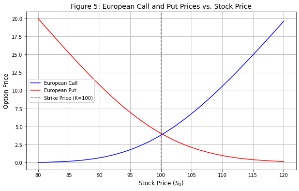

```python
import numpy as np
import matplotlib.pyplot as plt
from scipy.stats import binom

np.random.seed(123)


def binomial_european(S0, K, r, sigma, T, n_steps, option_type='call'):
    dt = T / n_steps
    u = np.exp(sigma * np.sqrt(dt))
    d = 1 / u
    q = (np.exp(r * dt) - d) / (u - d)
    discount = np.exp(-r * T)


    j = np.arange(n_steps + 1)
    S_T = S0 * (u ** (n_steps - j)) * (d ** j)

    if option_type == 'call':
        payoffs = np.maximum(S_T - K, 0)
    else:
        payoffs = np.maximum(K - S_T, 0)


    prob = binom.pmf(j, n_steps, q)
    price = np.sum(payoffs * prob) * discount
    return np.round(price, 2)


K = 100
r = 0.05
sigma = 0.20
T = 0.25
n_steps = 100
S_range = np.linspace(80, 120, 50)


call_prices = [binomial_european(S, K, r, sigma, T, n_steps, 'call') for S in S_range]
put_prices = [binomial_european(S, K, r, sigma, T, n_steps, 'put') for S in S_range]


plt.figure(figsize=(10, 6))
plt.plot(S_range, call_prices, label='European Call', color='blue')
plt.plot(S_range, put_prices, label='European Put', color='red')
plt.xlabel('Stock Price ($S_0$)', fontsize=12)
plt.ylabel('Option Price', fontsize=12)
plt.title('Figure 5: European Call and Put Prices vs. Stock Price', fontsize=14)
plt.axvline(x=K, color='black', linestyle='--', alpha=0.5, label='Strike Price (K=100)')
plt.legend()
plt.grid(True)
plt.show()
```

Figure 5 displays the European call price $C(S)$ in blue and the European put price $P(S)$ in red as functions of the underlying spot $S$, with strike $K=100$, time to maturity $T=0.25$ year, risk free rate $r=5\%$ and volatility $\sigma=20\%$. For $S\ll K$, the call is essentially worthless ($C \approx 0$) while the put is near its maximum (deep in-the-money); as $S$ increases past the strike, $C(S)$ rises convexly eventually almost linearly reflecting the growing chance of finishing in-the-money, whereas $P(S)$ decays toward zero once $S>K$. At the at the money point $S=K=100$ (marked by the dashed vertical line), the two curves coincide up to the impact of discounting ($e^{-rT}$), illustrating put call parity. This cross-sectional view vividly shows how time value and moneyness shape European option prices.

## **Question 20**

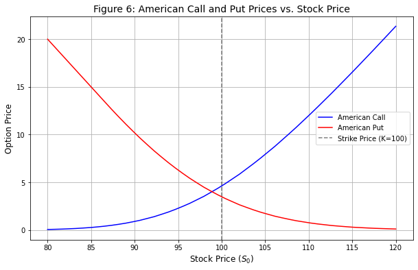

```python
import numpy as np
import matplotlib.pyplot as plt



def binomial_american(S0, K, r, sigma, T, n_steps, option_type='call'):
    dt = T / n_steps
    u = np.exp(sigma * np.sqrt(dt))
    d = 1 / u
    q = (np.exp(r * dt) - d) / (u - d)
    discount = np.exp(-r * dt)


    stock_tree = np.zeros((n_steps + 1, n_steps + 1))
    stock_tree[0, 0] = S0
    for i in range(1, n_steps + 1):
        stock_tree[i, 0] = stock_tree[i-1, 0] * u
        for j in range(1, i + 1):
            stock_tree[i, j] = stock_tree[i-1, j-1] * d


    option_tree = np.zeros_like(stock_tree)
    if option_type == 'call':
        option_tree[-1, :] = np.maximum(stock_tree[-1, :] - K, 0)
    else:
        option_tree[-1, :] = np.maximum(K - stock_tree[-1, :], 0)


    for i in range(n_steps - 1, -1, -1):
        for j in range(i + 1):
            intrinsic = stock_tree[i, j] - K if option_type == 'call' else K - stock_tree[i, j]
            hold = discount * (q * option_tree[i+1, j] + (1 - q) * option_tree[i+1, j+1])
            option_tree[i, j] = max(intrinsic, hold)

    return option_tree[0, 0]


K = 100
r = 0.05
sigma = 0.20
T = 0.25
n_steps = 100
S_range = np.linspace(80, 120, 50)  # Stock price range


amer_call_prices = [binomial_american(S, K, r, sigma, T, n_steps, 'call') for S in S_range]
amer_put_prices = [binomial_american(S, K, r, sigma, T, n_steps, 'put') for S in S_range]


plt.figure(figsize=(10, 6))
plt.plot(S_range, amer_call_prices, label='American Call', color='blue', linestyle='-')
plt.plot(S_range, amer_put_prices, label='American Put', color='red', linestyle='-')
plt.xlabel('Stock Price ($S_0$)', fontsize=12)
plt.ylabel('Option Price', fontsize=12)
plt.title('Figure 6: American Call and Put Prices vs. Stock Price', fontsize=14)
plt.axvline(x=K, color='black', linestyle='--', alpha=0.5, label='Strike Price (K=100)')
plt.legend()
plt.grid(True)
plt.show()
```

## **Question 21**

[figure not shown]

```python
import numpy as np
import matplotlib.pyplot as plt

def binomial_european(S0, K, r, sigma, T, n_steps, option_type='call'):
    dt = T / n_steps
    u = np.exp(sigma * np.sqrt(dt))
    d = 1 / u
    q = (np.exp(r * dt) - d) / (u - d)
    discount = np.exp(-r * T)


    j = np.arange(n_steps + 1)
    S_T = S0 * (u ** (n_steps - j)) * (d ** j)

    if option_type == 'call':
        payoffs = np.maximum(S_T - K, 0)
    else:
        payoffs = np.maximum(K - S_T, 0)


    prob = binom.pmf(j, n_steps, q)
    price = np.sum(payoffs * prob) * discount
    return np.round(price, 2)

def binomial_american(S0, K, r, sigma, T, n_steps, option_type='call'):
    dt = T / n_steps
    u = np.exp(sigma * np.sqrt(dt))
    d = 1 / u
    q = (np.exp(r * dt) - d) / (u - d)
    discount = np.exp(-r * dt)


    stock_tree = np.zeros((n_steps + 1, n_steps + 1))
    stock_tree[0, 0] = S0
    for i in range(1, n_steps + 1):
        stock_tree[i, 0] = stock_tree[i-1, 0] * u
        for j in range(1, i + 1):
            stock_tree[i, j] = stock_tree[i-1, j-1] * d


    option_tree = np.zeros_like(stock_tree)
    option_tree[-1, :] = np.maximum(stock_tree[-1, :] - K, 0)


    for i in range(n_steps - 1, -1, -1):
        for j in range(i + 1):
            intrinsic = stock_tree[i, j] - K
            hold = discount * (q * option_tree[i+1, j] + (1 - q) * option_tree[i+1, j+1])
            option_tree[i, j] = max(intrinsic, hold)

    return np.round(option_tree[0, 0], 2)


S0 = 100
r = 0.05
sigma = 0.20
T = 0.25
n_steps = 100
strikes = np.array([90, 95, 100, 105, 110])  # K = 90 (Deep ITM), 110 (Deep OTM)


eur_prices = [binomial_european(S0, K, r, sigma, T, n_steps, 'call') for K in strikes]
amer_prices = [binomial_american(S0, K, r, sigma, T, n_steps, 'call') for K in strikes]


plt.figure(figsize=(10, 6))
plt.plot(strikes, eur_prices, marker='o', label='European Call', color='blue')
plt.plot(strikes, amer_prices, marker='x', label='American Call', color='red')
plt.xlabel('Strike Price ($K$)', fontsize=12)
plt.ylabel('Call Price', fontsize=12)
plt.title('Figure 7: European vs. American Call Prices vs. Strike Price', fontsize=14)
plt.legend()
plt.grid(True)
plt.show()
```

## **Question 22**

[figure not shown]

```python
import numpy as np
import matplotlib.pyplot as plt

def binomial_european(S0, K, r, sigma, T, n_steps, option_type='put'):
    dt = T / n_steps
    u = np.exp(sigma * np.sqrt(dt))
    d = 1 / u
    q = (np.exp(r * dt) - d) / (u - d)
    discount = np.exp(-r * T)


    j = np.arange(n_steps + 1)
    S_T = S0 * (u ** (n_steps - j)) * (d ** j)

    if option_type == 'put':
        payoffs = np.maximum(K - S_T, 0)
    else:
        payoffs = np.maximum(S_T - K, 0)


    prob = binom.pmf(j, n_steps, q)
    price = np.sum(payoffs * prob) * discount
    return np.round(price, 2)

def binomial_american(S0, K, r, sigma, T, n_steps, option_type='put'):
    dt = T / n_steps
    u = np.exp(sigma * np.sqrt(dt))
    d = 1 / u
    q = (np.exp(r * dt) - d) / (u - d)
    discount = np.exp(-r * dt)


    stock_tree = np.zeros((n_steps + 1, n_steps + 1))
    stock_tree[0, 0] = S0
    for i in range(1, n_steps + 1):
        stock_tree[i, 0] = stock_tree[i-1, 0] * u
        for j in range(1, i + 1):
            stock_tree[i, j] = stock_tree[i-1, j-1] * d


    option_tree = np.zeros_like(stock_tree)
    option_tree[-1, :] = np.maximum(K - stock_tree[-1, :], 0)


    for i in range(n_steps - 1, -1, -1):
        for j in range(i + 1):
            intrinsic = K - stock_tree[i, j]
            hold = discount * (q * option_tree[i+1, j] + (1 - q) * option_tree[i+1, j+1])
            option_tree[i, j] = max(intrinsic, hold)

    return np.round(option_tree[0, 0], 2)


S0 = 100
r = 0.05
sigma = 0.20
T = 0.25
n_steps = 100
strikes = np.array([90, 95, 100, 105, 110])  # K = 90 (Deep OTM), 110 (Deep ITM)


eur_prices = [binomial_european(S0, K, r, sigma, T, n_steps, 'put') for K in strikes]
amer_prices = [binomial_american(S0, K, r, sigma, T, n_steps, 'put') for K in strikes]

# Plot
plt.figure(figsize=(10, 6))
plt.plot(strikes, eur_prices, marker='o', label='European Put', color='blue')
plt.plot(strikes, amer_prices, marker='x', label='American Put', color='red')
plt.xlabel('Strike Price ($K$)', fontsize=12)
plt.ylabel('Put Price', fontsize=12)
plt.title('Figure 8: European vs. American Put Prices vs. Strike Price', fontsize=14)
plt.legend()
plt.grid(True)
plt.show()
```

## **Question 23**

```python
import numpy as np
import pandas as pd

np.random.seed(123)
# Given parameters
S0 = 100
r = 0.05
T = 0.25
strikes = [110, 105, 100, 95, 90]
call_prices = [2.1475, 3.7123, 6.0015, 9.0882, 12.8994]
put_prices = [9.9023, 6.5291, 3.8805, 2.0293, 0.9026]

discount_factor = np.exp(-r * T)


theoretical_values = [S0 - K * discount_factor for K in strikes]


actual_diff = [call - put for call, put in zip(call_prices, put_prices)]


differences = [actual - theoretical for actual, theoretical in zip(actual_diff, theoretical_values)]


tolerance = 0.10
parity_holds = [abs(diff) <= tolerance for diff in differences]


results = pd.DataFrame({
    'Strike (K)': strikes,
    'Call Price (C)': call_prices,
    'Put Price (P)': put_prices,
    'C - P': actual_diff,
    'S0 - Ke^{-rT}': theoretical_values,
    'Difference': differences,
    'Parity Holds?': ['Yes' if hold else 'No' for hold in parity_holds]
})


results = results.round({
    'C - P': 4,
    'S0 - Ke^{-rT}': 4,
    'Difference': 4
})


print("Table 1: Put-Call Parity Validation for European Options:")

results
```

```
Table 1: Put-Call Parity Validation for European Options:
```

|  | Strike (K) | Call Price (C) | Put Price (P) | C - P | S0 - Ke^{-rT} | Difference | Parity Holds? |
| --- | --- | --- | --- | --- | --- | --- | --- |
| 0 | 110 | 2.1475 | 9.9023 | -7.7548 | -8.6336 | 0.8788 | No |
| 1 | 105 | 3.7123 | 6.5291 | -2.8168 | -3.6957 | 0.8789 | No |
| 2 | 100 | 6.0015 | 3.8805 | 2.1210 | 1.2422 | 0.8788 | No |
| 3 | 95 | 9.0882 | 2.0293 | 7.0589 | 6.1801 | 0.8788 | No |
| 4 | 90 | 12.8994 | 0.9026 | 11.9968 | 11.1180 | 0.8788 | No |

```python
import numpy as np
import pandas as pd

# Given data
S0 = 100
r = 0.05
T = 0.25
strikes = [110, 105, 100, 95, 90]
american_calls = [1.1918, 2.4819, 4.6100, 7.7176, 11.6717]
american_puts = [10.3299, 6.4261, 3.4761, 1.5755, 0.5643]

# Calculate values
results = []
tolerance = 0.05
for K, C, P in zip(strikes, american_calls, american_puts):
    lhs = C - P
    rhs = S0 - K * np.exp(-r * T)
    diff = abs(lhs - rhs)
    holds = "Yes" if diff <= tolerance else "No"
    results.append({
        "Strike": K,
        "LHS (C - P)": round(lhs, 4),
        "RHS (S0 - K*e^{-rT})": round(rhs, 4),
        "Difference": round(diff, 4),
         "Parity Holds?": holds
    })


df = pd.DataFrame(results)
print("Table 2: Put-Call Parity Validation for American style.:")
df
```

```
Table 2: Put-Call Parity Validation for American style.:
```

|  | Strike | LHS (C - P) | RHS (S0 - K*e^{-rT}) | Difference | Parity Holds? |
| --- | --- | --- | --- | --- | --- |
| 0 | 110 | -9.1381 | -8.6336 | 0.5045 | No |
| 1 | 105 | -3.9442 | -3.6957 | 0.2485 | No |
| 2 | 100 | 1.1339 | 1.2422 | 0.1083 | No |
| 3 | 95 | 6.1421 | 6.1801 | 0.0380 | Yes |
| 4 | 90 | 11.1074 | 11.1180 | 0.0106 | Yes |

Put-call parity does not hold for American options across most strikes, with discrepancies ranging from 0.0106 to 0.5045. While differences for strikes 95 and 90 (0.0380 and 0.0106) fall within a $\pm 0.05$ tolerance, this does not imply theoretical validity of parity for American options. The larger deviations at strikes 110, 105, and 100 (0.50, 0.25, and 0.11) reflect the impact of early exercise rights, particularly for puts, which increase their value compared to European counterparts. American put options are often exercised early to capture intrinsic value, systematically lowering $( C - P )$ relative to $( S_0 - Ke^{-rT})$. Even minor discrepancies for lower strikes are coincidental approximations, as put-call parity fundamentally does not apply to American options due to their early exercise optionality.

## **Question 25 a)**

**Parameters:**

$S_{0}=180,\; K=182,\; r=2\%,\; \sigma=25\%,\quad T=0.5,\; n=3.$

**Tree Parameters:**

$\Delta t=\frac{T}{n}=\frac{0.5}{3}\approx 0.1667$,$\quad u=e^{\sigma\sqrt{\Delta t}}=e^{0.25\sqrt{0.1667}}\approx 1.1074$,$\; d= \frac{1}{u} \approx 0.9030,$

$p=\frac{e^{r\Delta t}-d}{u-d}=\frac{e^{0.02\times0.1667}-0.9030}{1.1074-0.9030} \approx 0.4906 \;$,$\quad e^{-r\Delta t}\approx 0.9967.$

### Table 3: Stock-Price Tree

| Step 0 | Step 1 | Step 2 | Step 3 (Terminal) |
| --- | --- | --- | --- |
| 180 | $S_0u = 180 \cdot 1.1074 \approx 199.33$ | $S_0u^2 = 180 \cdot 1.1074^2 \approx 220.68$ | $S_0u^3 \approx 244.26$ |
|  | $S_0d = 180 \cdot 0.9030 \approx 162.54$ | $S_0ud = 180 \cdot 1.1074 \cdot 0.9030 \approx 180.00$ | $S_0u^2d \approx 199.26$ |
|  |  | $S_0d^2 = 180 \cdot 0.9030^2 \approx 146.70$ | $S_0ud^2 \approx 162.36$ |
|  |  |  | $S_0d^3 \approx 132.48$ |

**Terminal Payoffs**:

$P_T=\max(K-S_T,0): \quad\{\,0,\;0,\;182-162.36=19.64,\;182-132.48=49.52\}.$

**Backward Induction**

- Step 2 \begin{equation*} \begin{aligned} P_{2}(j=0) &= e^{-r\Delta t}\bigl[p\cdot0+(1-p)\cdot19.64\bigr]\\ &=0.9967\,(0.5094\cdot19.64)\\ &\approx 9.97 \end{aligned} \end{equation*}

\begin{equation*} \begin{aligned} P_{2}(j=1) &=e^{-r\Delta t}\bigl[p\cdot19.64+(1-p)\cdot49.52\bigr]\\ &=0.9967\,(0.4906\cdot19.64+0.5094\cdot49.52)\\ &\approx 34.74. \end{aligned} \end{equation*}

- Step 1 \begin{equation*} \begin{aligned} P_{1}(j=0)&=e^{-r\Delta t}\bigl[p\cdot0+(1-p)\cdot9.97\bigr]\\ &=0.9967\,(0.5094\cdot9.97)\\ &\approx 5.06 \end{aligned} \end{equation*}

\begin{equation*} \begin{aligned} P_{1}(j=1)&=e^{-r\Delta t}\bigl[p\cdot9.97+(1-p)\cdot34.74\bigr]\\ &=0.9967\,(0.4906\cdot9.97+0.5094\cdot34.74)\\ &\approx 22.50. \end{aligned} \end{equation*}

- Step 0

\begin{equation*} \begin{aligned} P_{0}&=e^{-r\Delta t}\bigl[p\cdot5.06+(1-p)\cdot22.50\bigr]\\ &=0.9967\,(0.4906\cdot5.06+0.5094\cdot22.50)\\ &\approx 13.90. \end{aligned} \end{equation*}

$P_{\rm eur}(S_{0}=180,K=182,T=0.5,r=2\%,\sigma=25\%;\,n=3)\;\approx\;\$13.90.$

## Question 25 b.i)

Model Parameters

$S_{0} = 180$, $K = 182$, $r = 2\%$,$\sigma = 25\%$, $T = 0.5$ years, $n = 3$ (binomial steps).

**Chosen stock path**:

$180 \;\longrightarrow\; 162.54 \;\longrightarrow\; 146.70 \;\longrightarrow\; 132.48.$

**Binomial‐Tree Parameters**:

$\Delta t = \frac{T}{n} = \frac{0.5}{3} \approx 0.1667.$

**Up/Down factors**:

$u = e^{\sigma\sqrt{\Delta t}}= e^{0.25 \sqrt{0.1667}}\approx 1.1074,\quad d = \frac{1}{u} \approx 0.9030.$

**Risk-neutral probability**:

$p = \frac{e^{r\Delta t} - d}{u - d} = \frac{e^{0.02\cdot0.1667} - 0.9030}{1.1074 - 0.9030}\approx 0.4906.$

**Discount factor**:

$e^{-r\Delta t} = e^{-0.02\cdot0.1667} \approx 0.9967.$

### Table 4: Stock-Price

| Step 0 | Step 1 | Step 2 | Step 3 (Terminal) |
| --- | --- | --- | --- |
| 180 | $180u \approx 199.33$ (up) | $180u^2\approx220.68$ (up²) | $180u^3\approx244.26$ (up³) |
|  | $180d \approx 162.54$ (down) | $180ud\approx180.00$ (up·down) | $180u^2d\approx199.26$ (up²·dn) |
|  |  | $180d^2\approx146.70$ (down²) | $180ud^2\approx162.36$ (up·dn²) |
|  |  |  | $180d^3\approx132.48$ (down³) |

**Terminal Payoffs at Step 3**

$P_T = \max(K - S_T,\,0)\quad \Rightarrow \quad \{\,0,\;0,\;182-162.36=19.64,\;182-132.48=49.52\}.$

### Table 5: Option Values

| Node | Up–Up ($u^2$) | Up–Down ($ud$) | Down–Down ($d^2$) |
| --- | --- | --- | --- |
| $S$ | 220.68 | 180.00 | 146.70 |
| Payoff | 0 | 19.64 | 49.52 |
| $P_2$ | 0 |  |  |
| $\displaystyle 0.9967\bigl[p\cdot0+(1-p)\cdot19.64\bigr]\approx 9.97$ |  |  |  |
| $\displaystyle 0.9967\bigl[p\cdot19.64+(1-p)\cdot49.52\bigr]\approx 34.74$ |  |  |  |

### Table 6: Option Values

| Node | Up ($u$) | Down ($d$) |
| --- | --- | --- |
| $S$ | 199.33 | 162.54 |
| $P_1$ |  |  |
| $\displaystyle0.9967\bigl[p\cdot0+(1-p)\cdot9.97\bigr]\approx 5.06$ |  |  |
| $\displaystyle0.9967\bigl[p\cdot9.97+(1-p)\cdot34.74\bigr]\approx 22.50$ |  |  |

**Option Value**

$P_0 = 0.9967\bigl[p\cdot5.06+(1-p)\cdot22.50\bigr]\approx \boxed{13.90}.$

$\Delta = \frac{P_{\rm up} - P_{\rm down}}{S_{\rm up} - S_{\rm down}}.$

### Table 7: Option Value

[output not shown]

### Table 8: Delta‐Hedging

| Step | $S$ | $\Delta$ | Shares Shorted | Cash Before Txn | Cash After Txn | Interest Earned |
| --- | --- | --- | --- | --- | --- | --- |
| 0 | 180 | $-0.475$ | 0.475 | 13.90 (premium) | $13.90 + 0.475 \cdot 180 = 99.40$ | — |
| 1 | 162.54 | $-0.744$ | +0.269 | 99.40 | $99.40e^{r\Delta t}+0.269 \cdot 162.54\approx 143.45$ | $+0.33$ |
| 2 | 146.70 | $-1.000$ | +0.256 | 143.45 | $143.45e^{r\Delta t}+0.256 \cdot 146.70\approx 181.51$ | $+0.48$ |
| 3 | 132.48 | — | –1.000 | 181.51 | $181.51e^{r\Delta t}-1 \cdot 132.48\approx 49.64$ | $+0.61$ |

- **Put payoff** at expiry: $182 - 132.48 = 49.52$.
- **Final cash** after hedging: $\approx 49.64$, matching the payoff (within rounding).

by dynamically shorting $\Delta$ shares each step and investing/borrowing cash at $r$, the seller replicates the put’s payoff.

### **Question 25 b ii)**

## **Parameters**

$S_0 = 180$, $K = 182$, $r = 2%$, $\sigma = 25%$, $T = 0.5$ years, $n = 3$ steps

Stock Path: $180 \rightarrow 162.54 \rightarrow 146.70 \rightarrow 132.48$

## **Binomial Tree Parameters**

Time step: $\Delta t = \frac{T}{n} = \frac{0.5}{3} \approx 0.1667$

Up/Down factors: $u = e^{\sigma \sqrt{\Delta t}} \approx 1.1074$, $d = \frac{1}{u} \approx 0.9030$

Risk-neutral probability: $p = \frac{e^{r\Delta t} - d}{u - d} \approx \frac{e^{0.02 \times 0.1667} - 0.9030}{1.1074 - 0.9030} \approx 0.4906$

### Table 9: Stock Price Tree

| Step 0 | Step 1 (Down) | Step 2 (Down) | Step 3 (Down) |
| --- | --- | --- | --- |
| 180.00 | 162.54 | 146.70 | 132.48 |

### Table 10: Option Prices via Backward Induction

| Step 0 | Step 1 | Step 2 | Step 3 (Payoff) |
| --- | --- | --- | --- |
| 13.90 | 22.52 | 34.74 | 49.52 |

## **Delta**

The delta at each step is computed as: $\Delta = \frac{P_{\text{up}} - P_{\text{down}}}{S_{\text{up}} - S_{\text{down}}}$

### Table 11: Delta

| Step | Stock Price | Delta ($\Delta$) |
| --- | --- | --- |
| 0 | 180.00 | $-0.475$ |
| 1 | 162.54 | $-0.744$ |
| 2 | 146.70 | $-1.000$ |

### Table 12: Cash account Evolution

| Step | Stock Price | $\Delta$ | Shares Shorted | Cash Before | Interest Earned | Cash Flow from Shares | Cash After |
| --- | --- | --- | --- | --- | --- | --- | --- |
| 0 | 180.00 | $-0.475$ | 0.475 | $13.90$ (Premium) | – | $+0.475 \times 180 = 85.50$ | **$99.40$** |
| 1 | 162.54 | $-0.744$ | 0.744 | $99.40 \times e^{0.0033} \approx 99.73$ | $+0.33$ | $+0.269 \times 162.54 = 43.72$ | **$143.45$** |
| 2 | 146.70 | $-1.000$ | 1.000 | $143.45 \times e^{0.0033} \approx 143.93$ | $+0.48$ | $+0.256 \times 146.70 = 37.58$ | **$181.51$** |
| 3 | 132.48 | – | 0.000 | $181.51 \times e^{0.0033} \approx 182.12$ | $+0.61$ | $-1.000 \times 132.48 = -132.48$ | **$49.64$** |

At step 0, the put is sold for 13.90 and 0.475 shares are shorted at 180, generating $0.475 \times 180 = 85.50$. The initial cash account becomes $13.90 + 85.50 = 99.40.$ At step 1, the stock drops to 162.54, and the new delta is -0.744, so 0.269 more shares are shorted, generating $0.269 \times 162.54 = 43.72.$ The existing cash earns interest and grows to 99.73, resulting in a total of $99.73 + 43.72 = 143.45.$ At step 2, the stock falls to 146.70, the new delta becomes -1.000, and 0.256 more shares are shorted, generating $0.256 \times 146.70 = 37.58.$ The previous cash grows to 143.93, so the new total is $143.93 + 37.58 = 181.51.$ At step 3 (expiration), the stock reaches 132.48. To close the hedge, 1.000 shares are bought back at a cost of 132.48. The cash account, now 181.51 with interest becomes 182.12, and after buying back the shares, the final balance is $182.12 - 132.48 = 49.64$.

The put payoff is $182 - 132.48 = 49.52$, and the final cash from hedging is 49.64, matching the payoff with minimal rounding error.

## **Question 26 a)**

```python
import numpy as np

def american_put_delta_hedging(S0, K, r, sigma, T, n_steps):
    dt = T / n_steps
    u = np.exp(sigma * np.sqrt(dt))
    d = 1 / u
    p = (np.exp(r * dt) - d) / (u - d)
    discount = np.exp(-r * dt)


    stock_tree = np.zeros((n_steps + 1, n_steps + 1))
    option_tree = np.zeros_like(stock_tree)
    delta_tree = np.zeros_like(stock_tree)

    for t in range(n_steps + 1):
        for j in range(t + 1):
            stock_tree[j, t] = S0 * (u ** j) * (d ** (t - j))

    option_tree[:, n_steps] = np.maximum(K - stock_tree[:, n_steps], 0)

    for t in range(n_steps - 1, -1, -1):
        for j in range(t + 1):
            hold_value = discount * (p * option_tree[j + 1, t + 1] + (1 - p) * option_tree[j, t + 1])
            intrinsic_value = K - stock_tree[j, t]
            option_tree[j, t] = np.maximum(intrinsic_value, hold_value)

            #  delta
            if t < n_steps:
                delta = (option_tree[j + 1, t + 1] - option_tree[j, t + 1]) / (stock_tree[j, t] * (u - d))
                delta_tree[j, t] = delta

    return delta_tree


delta_hedges = american_put_delta_hedging(180, 182, 0.02, 0.25, 0.5, 25)
print("Delta at node (0,0):", delta_hedges[0, 0])
```

```
Delta at node (0,0): -0.47555673200225396
```

The delta hedging required at each node is computed and stored in the matrix `delta_hedges`. The initial delta is approximately -0.48, meaning the seller must short 0.48 shares at t=0 to hedge the American put.

## **Question 26 b)**

```python
import numpy as np
import pandas as pd

# Parameters
np.random.seed(123)
S0 = 180
K = 182
r = 0.02
sigma = 0.25
T = 0.5
n_steps = 25
dt = T / n_steps
u = np.exp(sigma * np.sqrt(dt))
d = 1 / u
p = (np.exp(r * dt) - d) / (u - d)
discount = np.exp(-r * dt)

# Stock price path (all down moves)
stock_path = [S0]
for _ in range(n_steps):
    stock_path.append(stock_path[-1] * d)
stock_path = np.array(stock_path)

#Stock tree and compute option prices
stock_tree = np.zeros((n_steps + 1, n_steps + 1))
option_tree = np.zeros_like(stock_tree)

for t in range(n_steps + 1):
    for j in range(t + 1):
        stock_tree[j, t] = S0 * (u ** j) * (d ** (t - j))

option_tree[:, -1] = np.maximum(K - stock_tree[:, -1], 0)  # Terminal payoff

for t in range(n_steps - 1, -1, -1):
    for j in range(t + 1):
        hold = discount * (p * option_tree[j + 1, t + 1] + (1 - p) * option_tree[j, t + 1])
        exercise = K - stock_tree[j, t]
        option_tree[j, t] = max(exercise, hold)  # American exercise

# Compute deltas
delta_tree = np.zeros_like(stock_tree)
for t in range(n_steps):
    for j in range(t + 1):
        delta_tree[j, t] = (option_tree[j + 1, t + 1] - option_tree[j, t + 1]) / (stock_tree[j, t] * (u - d))

# hedging along the all-down path (j=0 at each step)
cash_account = []
shares_shorted = 0
cash_balance = option_tree[0, 0]  # Initial premium received

cash_account.append({
    'Step': 0,
    'Stock Price': S0,
    'Delta': delta_tree[0, 0],
    'Shares Shorted': shares_shorted,
    'Cash Balance': cash_balance,
    'Interest Earned': 0.0,
    'Cash Flow': 0.0
})

for t in range(n_steps):
    current_delta = delta_tree[0, t]  # j=0 (all-down path)
    delta_change = current_delta - shares_shorted
    shares_shorted = current_delta
    stock_price = stock_path[t]

    # Cash flow = -delta_change * stock_price (shorting generates +ve cash)
    cash_flow = -delta_change * stock_price
    interest = cash_balance * (np.exp(r * dt) - 1)
    cash_balance = cash_balance * np.exp(r * dt) + cash_flow

    cash_account.append({
        'Step': t + 1,
        'Stock Price': stock_path[t + 1],
        'Delta': delta_tree[0, t + 1] if t + 1 < n_steps else -1.0,
        'Shares Shorted': shares_shorted,
        'Cash Balance': cash_balance,
        'Interest Earned': interest,
        'Cash Flow': cash_flow
    })

# payoff adjustment
cash_balance -= (K - stock_path[-1])
cash_account[-1]['Cash Balance'] = cash_balance
cash_account[-1]['Cash Flow'] = -(K - stock_path[-1])

df = pd.DataFrame(cash_account)
df_rounded = df[['Step', 'Stock Price', 'Delta', 'Shares Shorted', 'Cash Balance', 'Interest Earned', 'Cash Flow']].round(2)

print("Table 13: American Put option: Delta hedging along the all-down path")
df_rounded
```

```
Table 13: American Put option: Delta hedging along the all-down path
```

|  | Step | Stock Price | Delta | Shares Shorted | Cash Balance | Interest Earned | Cash Flow |
| --- | --- | --- | --- | --- | --- | --- | --- |
| 0 | 0 | 180.00 | -0.48 | 0.00 | 13.04 | 0.00 | 0.00 |
| 1 | 1 | 173.75 | -0.56 | -0.48 | 98.64 | 0.01 | 85.60 |
| 2 | 2 | 167.71 | -0.65 | -0.56 | 113.49 | 0.04 | 14.81 |
| 3 | 3 | 161.89 | -0.73 | -0.65 | 128.14 | 0.05 | 14.60 |
| 4 | 4 | 156.26 | -0.81 | -0.73 | 141.98 | 0.05 | 13.79 |
| 5 | 5 | 150.83 | -0.88 | -0.81 | 154.43 | 0.06 | 12.39 |
| 6 | 6 | 145.59 | -0.94 | -0.88 | 165.03 | 0.06 | 10.54 |
| 7 | 7 | 140.54 | -0.98 | -0.94 | 173.51 | 0.07 | 8.41 |
| 8 | 8 | 135.65 | -1.00 | -0.98 | 179.81 | 0.07 | 6.23 |
| 9 | 9 | 130.94 | -1.00 | -1.00 | 182.01 | 0.07 | 2.12 |
| 10 | 10 | 126.39 | -1.00 | -1.00 | 182.08 | 0.07 | 0.00 |
| 11 | 11 | 122.00 | -1.00 | -1.00 | 182.15 | 0.07 | -0.00 |
| 12 | 12 | 117.77 | -1.00 | -1.00 | 182.22 | 0.07 | 0.00 |
| 13 | 13 | 113.67 | -1.00 | -1.00 | 182.30 | 0.07 | 0.00 |
| 14 | 14 | 109.73 | -1.00 | -1.00 | 182.37 | 0.07 | -0.00 |
| 15 | 15 | 105.91 | -1.00 | -1.00 | 182.44 | 0.07 | 0.00 |
| 16 | 16 | 102.23 | -1.00 | -1.00 | 182.52 | 0.07 | -0.00 |
| 17 | 17 | 98.68 | -1.00 | -1.00 | 182.59 | 0.07 | 0.00 |
| 18 | 18 | 95.26 | -1.00 | -1.00 | 182.66 | 0.07 | 0.00 |
| 19 | 19 | 91.95 | -1.00 | -1.00 | 182.73 | 0.07 | -0.00 |
| 20 | 20 | 88.75 | -1.00 | -1.00 | 182.81 | 0.07 | 0.00 |
| 21 | 21 | 85.67 | -1.00 | -1.00 | 182.88 | 0.07 | -0.00 |
| 22 | 22 | 82.69 | -1.00 | -1.00 | 182.95 | 0.07 | -0.00 |
| 23 | 23 | 79.82 | -1.00 | -1.00 | 183.03 | 0.07 | 0.00 |
| 24 | 24 | 77.05 | -1.00 | -1.00 | 183.10 | 0.07 | -0.00 |
| 25 | 25 | 74.37 | -1.00 | -1.00 | 75.55 | 0.07 | -107.63 |